# Untitled

Richard Leigh

29 January 2019

## Information

This README demonstrates the coding procedure behind the assignment. This file shows the Filtered Historical Simulation (FHS) analysis of Value at Risk (VaR) for STANLIB Global Balanced Feeder Fund B only, since the procedure is repeated identically for each fund. Only the specified fits of ARIMA and GARCH models vary slightly with each fund.

Lastly, the code functions also contain details in the form of comments to explain the relevant code chunks and their purpose.

### Set Up

The relevant packages are loaded along with the Data.

```r
library(rmsfuns)
library(xtable)
library(Texevier)

packagestoload <- c("xts", "tidyverse", "devtools", "rugarch", "forecast", "tbl2xts", "PerformanceAnalytics", "dplyr", "lubridate", "glue", "ggthemes", "ggplot2", "Texevier", "parallel", "readr", "readxl")
load_pkg(packagelist = packagestoload)

# removing packages to avoid clutter in global enviroment
rm(list=ls())

# loading Data
Data <- read_excel("data/Data.xlsx")
```

## 1. Log Returns

Log return for STANLIB Global Balanced Feeder Fund B are first calculated from prices.

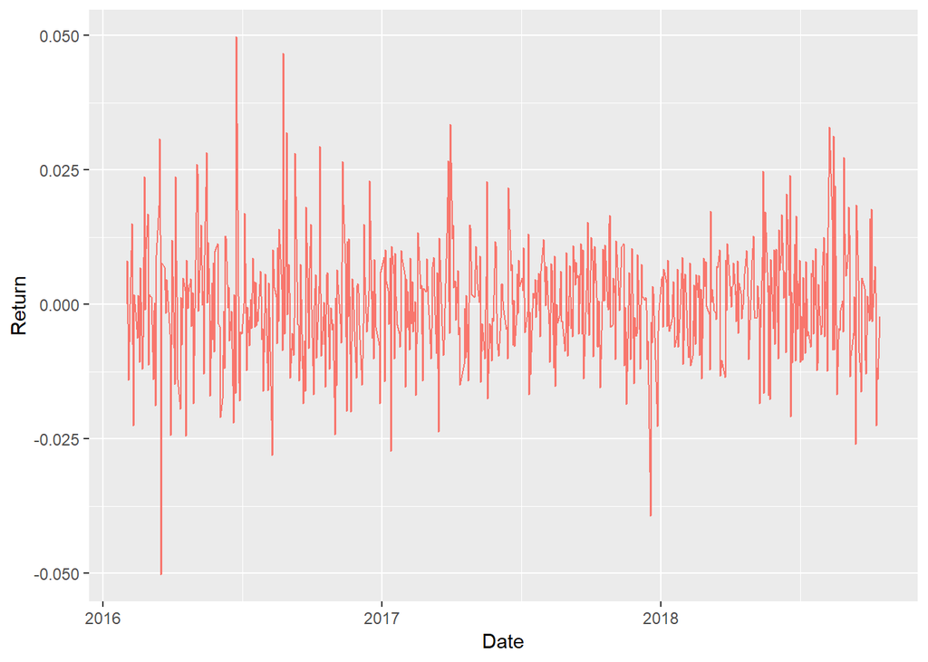

```r
source("code/DLog_func.R")
Data <- DLog_func(Data)

Data %>%
  group_by(FundName) %>%
  filter(FundName == "STANLIB Global Balanced Feeder Fund B") %>%
  filter(Date >= as.Date("2016-02-01"), Date <= as.Date("2018-10-15")) %>%
  ggplot() + geom_line(aes(x = Date, y = Return, colour = FundName)) + theme(legend.position = "none")
```

## 2. Cumulative Returs

Fitting the GARCH model requires cumulative returns, hence cumulative returns for STANLIB Global Balanced Feeder Fund B are calculated from the log returns.

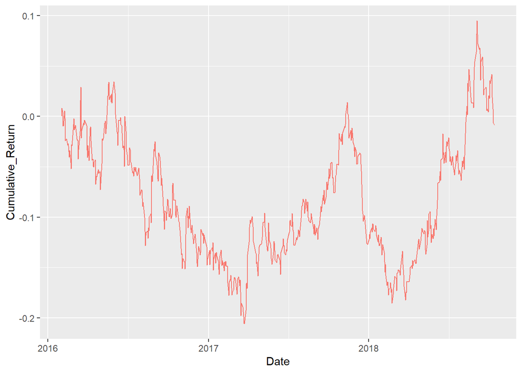

```r
source("code/Cumret_func.R")
Data <- Cumret_func(Data)

Data %>%
  group_by(FundName) %>%
  filter(FundName == "STANLIB Global Balanced Feeder Fund B") %>%
  filter(Date >= as.Date("2016-02-01"), Date <= as.Date("2018-10-15")) %>%
  ggplot() + geom_line(aes(x = Date, y = Cumulative_Return, colour = FundName)) + theme(legend.position = "none")
```

## 3. Fitting ARIMA and GARCH Models

```r
source("code/H1_GARCH_func.R")
H1_fit <- H1_GARCH_func(Data)
```

## 4. Standardized Residuals

The residuals filtered to produce close to i.i.d Stationary standardized residuals.

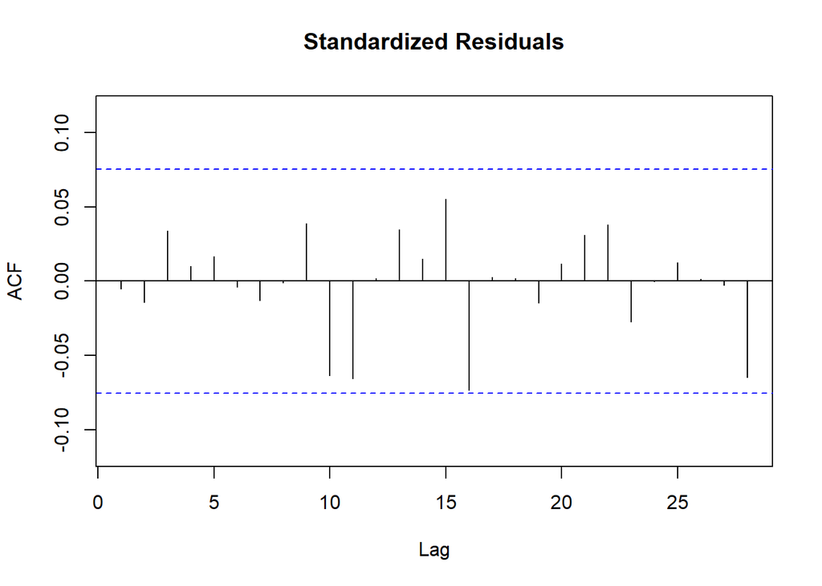

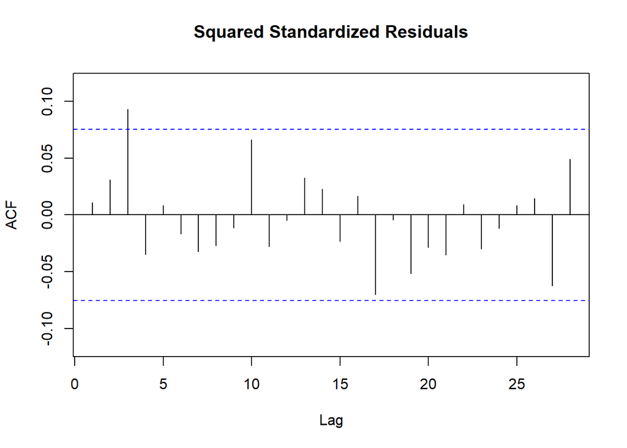

```r
source("code/H1_st_resids_func.R")
H1_st_resids_func(Data)
```

## 5. Simulating 1 Week Ahead

100 simulation paths of one week are simulated from 16 October 2018 to 22 October 2018.

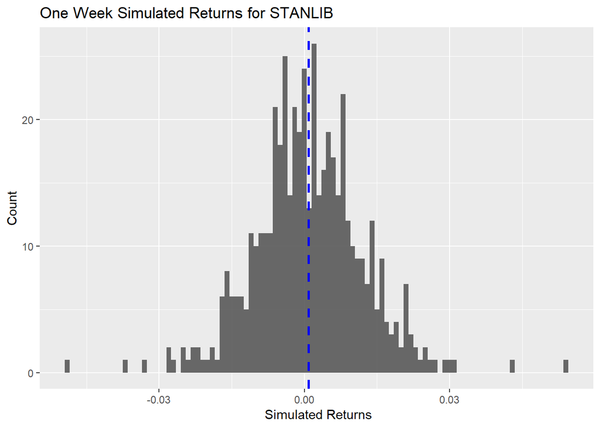

```r
source("code/H1_sim_1W_func.R")
H1_sim_1W <- H1_sim_1W_func(H1_fit)

# Histogram of 1 week simulations
source("code/H1_sim_1W_histogram.R")
H1_sim_1W_histogram(H1_sim_1W)
```

## 6. Simulating 1 Month Ahead

100 simulation paths of one month are simulated from 16 October 2018 to 15 November 2018.

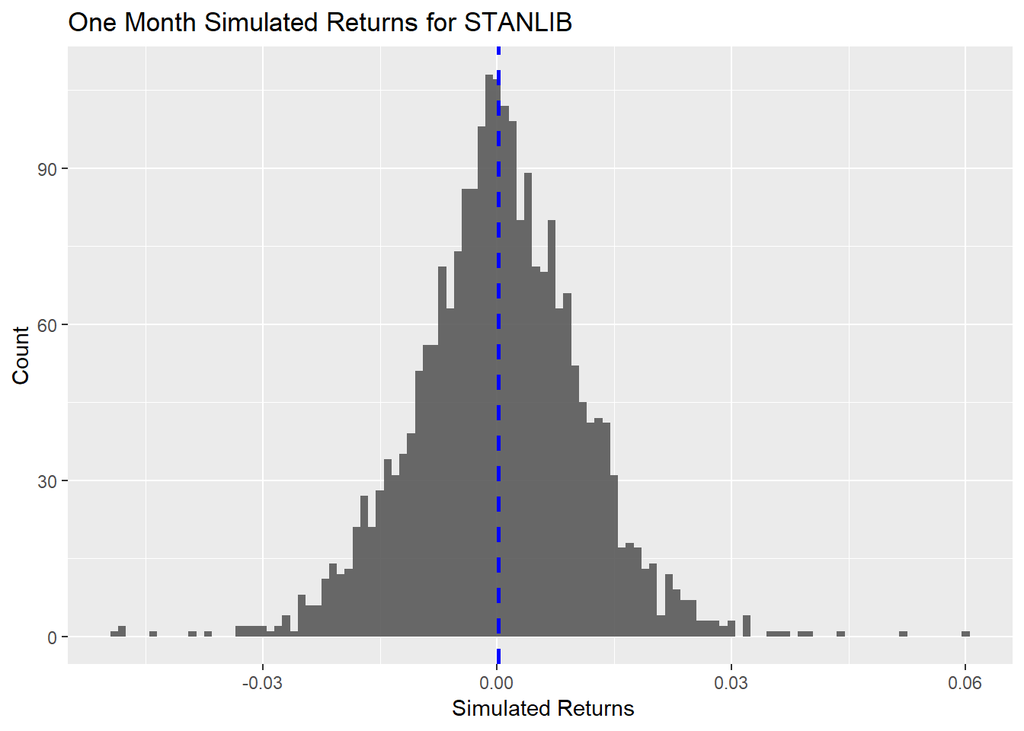

```r
source("code/H1_sim_1M_func.R")
H1_sim_1M <- H1_sim_1M_func(H1_fit)

# Histogram of 1 month simulations
source("code/H1_sim_1M_histogram.R")
H1_sim_1M_histogram(H1_sim_1M)
```

## 7. Calculating the VaR for both Simulated Periods

The VaR is calculated for both the one-week and one-month simulated pathways.

```r
# VaR for simulations (1 Week from 2018-10-16 to 2018-10-22)
source("code/H1_VaR_1W_sim_func.R")
H1_VaR_1W_sim <- H1_VaR_1W_sim_func(H1_sim_1W)

# VaR for simulations (1 Month from 2018-10-16 to 2018-11-15)
source("code/H1_VaR_1M_sim_func.R")
H1_VaR_1M_sim <- H1_VaR_1M_sim_func(H1_sim_1M)
```

## 8. Calculating the actual VaR from Historical Data

Using the historical values for the one-week and one-month time periods (16 October 2018 to 22 October 2018. and 16 October 2018 to 15 November 2018.), the VaR is calculated to compare with the VaR of the simulated pathways. Thus, the predictive strength of the FHS in determining VaR of can be compared with actual data.

```r
# Historical VaR (1 Week 2018-10-16 to 2018-10-22)
source("code/H1_VaR_1W_hist_func.R")
H1_VaR_1W_hist <- H1_VaR_1W_hist_func(Data)

# Historical VaR (1 Month 2018-10-16 to 2018-11-15 )
source("code/H1_VaR_1M_hist_func.R")
H1_VaR_1M_hist <- H1_VaR_1M_hist_func(Data)
```

## 9. Table to Compare VaR estimates

A table is created to directly compare the VaR’s of the simulated periods and the VaR of the historical data for those periods.

NB! this table is produced in LateX and will not be shown in the README.

```r
source("code/H1_VaR_table.R")
H1_VaR_table()
```

The following code chunk provides a matrix of the VaR table to see the comparison of VaR’s

```r
H1_VaR <- matrix(c(H1_VaR_1W_sim, H1_VaR_1M_sim, H1_VaR_1W_hist, H1_VaR_1M_hist),ncol=2,byrow=TRUE)
#H1_VaR <- H1_VaR %>% as.data.frame()
colnames(H1_VaR) <- c("One-Week", "One-Month")
rownames(H1_VaR) <- c("FHS","Historical")

print(H1_VaR)
```

```
##                One-Week   One-Month
## FHS        -0.016916520 -0.01710130
## Historical -0.008946389 -0.01246722
```